# Project: Investigate a Dataset ( No-Show Appointments 'Brazil' )

- Introduction
- Data Wrangling
- Exploratory Data Analysis
- Conclusions

## Introduction

Our **Purpose** is to Data analysis on a sample Dataset to try to understand the possible reasons for the patients from the sample not to attend their appointments, then try to allocate resources to solve those issues to give patients better health care.

```python
# Import Libraries
import numpy as np
import pandas as pd
import seaborn as sns
import matplotlib.pyplot as plt
%matplotlib inline
```

## Data Wrangling

### Data Description

> This dataset collects information from 100k medical appointments in Brazil and is focused on the question of whether or not patients show up for their appointment. A number of characteristics about the patient are included in each row.  
> - ‘ScheduledDay’ tells us on what day the patient set up their appointment.  
> - ‘Neighborhood’ indicates thelocation of the hospital.  
> - ‘Scholarship’ indicates whether or not the patient is enrolled in Brasilian welfare program Bolsa Família.  
> - Be careful about the encoding of the last column: it says ‘No’ if the patient showed up to their appointment, and ‘Yes’ if they did not show up.  
> - ‘Category ’ Categorize according to gender and age (Child, Man, Women,Elderly People).

### General Properties

```python
# Read in the Dataset, create dataframe
df = pd.read_csv('noshowappointments-kagglev2-may-2016.csv')
```

```python
# Print the first few records to review data and format
df.head()
```

|  | PatientId | AppointmentID | Gender | ScheduledDay | AppointmentDay | Age | Neighbourhood | Scholarship | Hipertension | Diabetes | Alcoholism | Handcap | SMS_received | No-show |
| --- | --- | --- | --- | --- | --- | --- | --- | --- | --- | --- | --- | --- | --- | --- |
| 0 | 2.987250e+13 | 5642903 | F | 2016-04-29T18:38:08Z | 2016-04-29T00:00:00Z | 62 | JARDIM DA PENHA | 0 | 1 | 0 | 0 | 0 | 0 | No |
| 1 | 5.589978e+14 | 5642503 | M | 2016-04-29T16:08:27Z | 2016-04-29T00:00:00Z | 56 | JARDIM DA PENHA | 0 | 0 | 0 | 0 | 0 | 0 | No |
| 2 | 4.262962e+12 | 5642549 | F | 2016-04-29T16:19:04Z | 2016-04-29T00:00:00Z | 62 | MATA DA PRAIA | 0 | 0 | 0 | 0 | 0 | 0 | No |
| 3 | 8.679512e+11 | 5642828 | F | 2016-04-29T17:29:31Z | 2016-04-29T00:00:00Z | 8 | PONTAL DE CAMBURI | 0 | 0 | 0 | 0 | 0 | 0 | No |
| 4 | 8.841186e+12 | 5642494 | F | 2016-04-29T16:07:23Z | 2016-04-29T00:00:00Z | 56 | JARDIM DA PENHA | 0 | 1 | 1 | 0 | 0 | 0 | No |

```python
#Returns The Shape of the data
df.shape
```

```
(110527, 14)
```

```python
#Check for Any Missing Values of the data
df.info()
```

```
<class 'pandas.core.frame.DataFrame'>
RangeIndex: 110527 entries, 0 to 110526
Data columns (total 14 columns):
 #   Column          Non-Null Count   Dtype
---  ------          --------------   -----
 0   PatientId       110527 non-null  float64
 1   AppointmentID   110527 non-null  int64
 2   Gender          110527 non-null  object
 3   ScheduledDay    110527 non-null  object
 4   AppointmentDay  110527 non-null  object
 5   Age             110527 non-null  int64
 6   Neighbourhood   110527 non-null  object
 7   Scholarship     110527 non-null  int64
 8   Hipertension    110527 non-null  int64
 9   Diabetes        110527 non-null  int64
 10  Alcoholism      110527 non-null  int64
 11  Handcap         110527 non-null  int64
 12  SMS_received    110527 non-null  int64
 13  No-show         110527 non-null  object
dtypes: float64(1), int64(8), object(5)
memory usage: 11.8+ MB
```

```python
#Check for Any Missing Values of the data
df.isnull().sum()
```

```
PatientId         0
AppointmentID     0
Gender            0
ScheduledDay      0
AppointmentDay    0
Age               0
Neighbourhood     0
Scholarship       0
Hipertension      0
Diabetes          0
Alcoholism        0
Handcap           0
SMS_received      0
No-show           0
dtype: int64
```

**Conclusion:** There is no missing data or null values.

```python
#Brief statistical description about the data
df.describe()
```

|  | PatientId | AppointmentID | Age | Scholarship | Hipertension | Diabetes | Alcoholism | Handcap | SMS_received |
| --- | --- | --- | --- | --- | --- | --- | --- | --- | --- |
| count | 1.105270e+05 | 1.105270e+05 | 110527.000000 | 110527.000000 | 110527.000000 | 110527.000000 | 110527.000000 | 110527.000000 | 110527.000000 |
| mean | 1.474963e+14 | 5.675305e+06 | 37.088874 | 0.098266 | 0.197246 | 0.071865 | 0.030400 | 0.022248 | 0.321026 |
| std | 2.560949e+14 | 7.129575e+04 | 23.110205 | 0.297675 | 0.397921 | 0.258265 | 0.171686 | 0.161543 | 0.466873 |
| min | 3.921784e+04 | 5.030230e+06 | -1.000000 | 0.000000 | 0.000000 | 0.000000 | 0.000000 | 0.000000 | 0.000000 |
| 25% | 4.172614e+12 | 5.640286e+06 | 18.000000 | 0.000000 | 0.000000 | 0.000000 | 0.000000 | 0.000000 | 0.000000 |
| 50% | 3.173184e+13 | 5.680573e+06 | 37.000000 | 0.000000 | 0.000000 | 0.000000 | 0.000000 | 0.000000 | 0.000000 |
| 75% | 9.439172e+13 | 5.725524e+06 | 55.000000 | 0.000000 | 0.000000 | 0.000000 | 0.000000 | 0.000000 | 1.000000 |
| max | 9.999816e+14 | 5.790484e+06 | 115.000000 | 1.000000 | 1.000000 | 1.000000 | 1.000000 | 4.000000 | 1.000000 |

- Mean Age of the patients equals 37 years old.
- Maximum Age of the patients equals 115 years old.
- The is a mistake with one of the patients' age as it shows that the age equals -1.

```python
# Check datatypes of dataframe coloumn to ensure convenient types
df.dtypes
```

```
PatientId         float64
AppointmentID       int64
Gender             object
ScheduledDay       object
AppointmentDay     object
Age                 int64
Neighbourhood      object
Scholarship         int64
Hipertension        int64
Diabetes            int64
Alcoholism          int64
Handcap             int64
SMS_received        int64
No-show            object
dtype: object
```

# Cleaning Data

**Remove unnecessary columns:** We will not use the PatientId, AppointmentID, ScheduledDay, and AppointmentDay. So, We will start cleaning by dropping those coloumns.

```python
df.drop(['PatientId','AppointmentID','ScheduledDay','AppointmentDay'],axis=1,inplace=True)
```

```python
# Print the first few records to review data and format
df.head()
```

|  | Gender | Age | Neighbourhood | Scholarship | Hipertension | Diabetes | Alcoholism | Handcap | SMS_received | No-show |
| --- | --- | --- | --- | --- | --- | --- | --- | --- | --- | --- |
| 0 | F | 62 | JARDIM DA PENHA | 0 | 1 | 0 | 0 | 0 | 0 | No |
| 1 | M | 56 | JARDIM DA PENHA | 0 | 0 | 0 | 0 | 0 | 0 | No |
| 2 | F | 62 | MATA DA PRAIA | 0 | 0 | 0 | 0 | 0 | 0 | No |
| 3 | F | 8 | PONTAL DE CAMBURI | 0 | 0 | 0 | 0 | 0 | 0 | No |
| 4 | F | 56 | JARDIM DA PENHA | 0 | 1 | 1 | 0 | 0 | 0 | No |

```python
# Rename No-show to No_show
df.rename(columns= lambda x: x.replace('-','_'),inplace=True)
```

### Exploring Handcap Coloumn to ensure that there is no wrong entries.

```python
print(df['Handcap'].describe())
print(df['Handcap'].unique())
```

```
count    110527.000000
mean          0.022248
std           0.161543
min           0.000000
25%           0.000000
50%           0.000000
75%           0.000000
max           4.000000
Name: Handcap, dtype: float64
[0 1 2 3 4]
```

**Observation:** It was found that Handcap coloumn states either patient is handcapped or not (0 or 1), but it was found that there is a values of 2, 3, and 4 so we had to remove them.

```python
i = 2
for i in range (2,5):
    index_names = df[df['Handcap'] == i].index
    df.drop(index_names, inplace=True)
```

**Verify results:**

```python
df['Handcap'].unique()
```

```
array([0, 1], dtype=int64)
```

#### Exploring Age column to ensure that there is no wrong entries.

```python
df['Age'].describe()
```

```
count    110328.000000
mean         37.070408
std          23.098231
min          -1.000000
25%          18.000000
50%          37.000000
75%          55.000000
max         115.000000
Name: Age, dtype: float64
```

**Observation:** It was found that Age coloumn contains an age of -1 which is considered to be a false entry so we had to remove that.

```python
index_names = df[df['Age'] < 0].index
df.drop(index_names,inplace=True)
```

**Verify results:**

```python
df['Age'].describe()
```

```
count    110327.000000
mean         37.070753
std          23.098052
min           0.000000
25%          18.000000
50%          37.000000
75%          55.000000
max         115.000000
Name: Age, dtype: float64
```

#### Exploring Dataset rest Coloumns to ensure that there is no wrong entries.

```python
df['Hipertension'].unique()
```

```
array([1, 0], dtype=int64)
```

```python
df['Alcoholism'].unique()
```

```
array([0, 1], dtype=int64)
```

```python
df['Diabetes'].unique()
```

```
array([0, 1], dtype=int64)
```

```python
df['Scholarship'].unique()
```

```
array([0, 1], dtype=int64)
```

```python
df['SMS_received'].unique()
```

```
array([0, 1], dtype=int64)
```

**Explanation:** 0 Value means that the patient doesn't have this charactaristic while 1 means that patient have this charactaristic.

```python
df['Gender'].unique()
```

```
array(['F', 'M'], dtype=object)
```

**Explanation:** F is For Female, while M is for Male.

### Categorize people into four categories according to Age & Gender (child, Woman, Man, elderly) to ease some studies.

**Assumption:** With 'child' and 'Elderly People' not classified in the data, I'll need to assume a cutoff point. Therefore, I'll be using today's standard of under 18 as those to be considered as a child and over 60 considered as elderly people.

```python
# Split Patients into four categories according to Gender & Age to ease the study.
df.loc[((df['Gender'] == 'F') &(df['Age'] >= 18)),'Category'] = 'Woman'
df.loc[((df['Gender'] == 'M') & (df['Age'] >= 18)),'Category'] = 'Man'
df.loc[(df['Age'] < 18),'Category'] = 'Child'
df.loc[(df['Age'] > 60),'Category'] = 'Elderly'
```

```python
df.head()
```

|  | Gender | Age | Neighbourhood | Scholarship | Hipertension | Diabetes | Alcoholism | Handcap | SMS_received | No_show | Category |
| --- | --- | --- | --- | --- | --- | --- | --- | --- | --- | --- | --- |
| 0 | F | 62 | JARDIM DA PENHA | 0 | 1 | 0 | 0 | 0 | 0 | No | Elderly |
| 1 | M | 56 | JARDIM DA PENHA | 0 | 0 | 0 | 0 | 0 | 0 | No | Man |
| 2 | F | 62 | MATA DA PRAIA | 0 | 0 | 0 | 0 | 0 | 0 | No | Elderly |
| 3 | F | 8 | PONTAL DE CAMBURI | 0 | 0 | 0 | 0 | 0 | 0 | No | Child |
| 4 | F | 56 | JARDIM DA PENHA | 0 | 1 | 1 | 0 | 0 | 0 | No | Woman |

## Exploratory Data Analysis

### General Data Showing

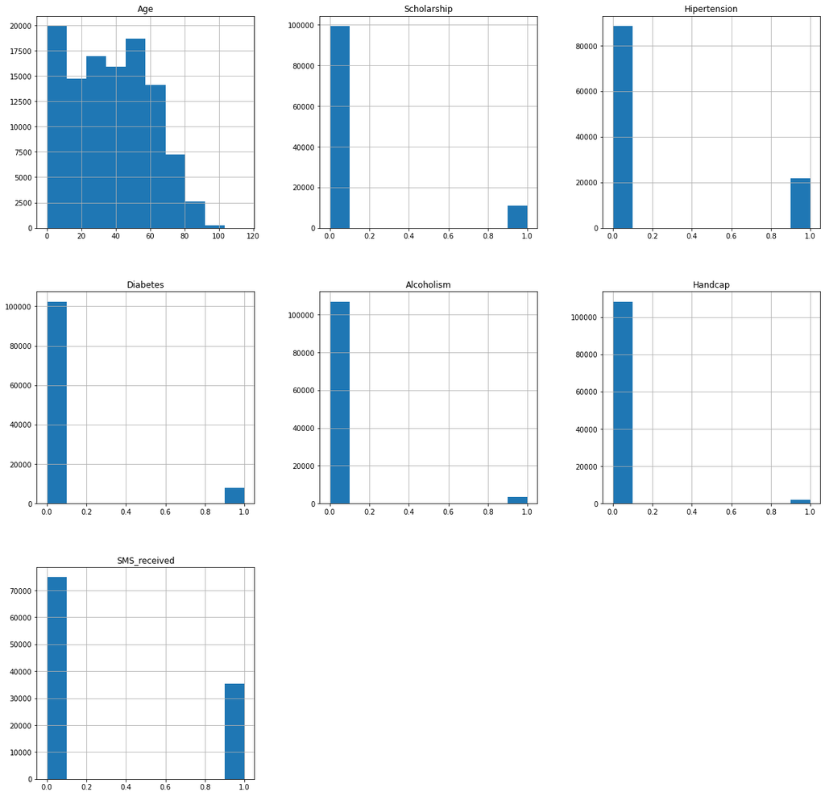

```python
df.hist(figsize=[20,20]);
```

```python
def plotting(df,char_1,char_2,plot_kind,fig_size):
    '''
    This function is used to plot a graph to describe the Numbers of patients with certain charactaristic(s) who attended or didn't attend there appointments.
    Arrguments:
    df: DataFrame which includes the charactaristics we want to study its influence on attending, with a coloumn that shows if the patients attend or not.
    char_1: Coloumn name that shows if the patients attend or not with values that must be like follows ('No' for attending the appointment & 'Yes' for skipping the appointment).
    char_2: The Charactaristic we want to study its influence on showing or not showing for appointment
    plot_kind: Either Histogram or Bar(Horizontal or Vertical) entries can be as follows('hist', 'bar', 'barh')
    fig_size: list of length and width of the desired graph (ex. [10,10])
    '''
    #Assign Names to patients who showed and doesn't showed to make the recalling and comparison easier.
    Show = df[char_1] == 'No'
    No_Show = df[char_1] == 'Yes'
    char_show = df[char_2][Show]
    char_no_show = df[char_2][No_Show]
    if plot_kind == 'hist':
        plt.figure(figsize= fig_size)
        plt.hist(char_show,alpha=0.5,label='Showed for appointment',color='Blue',edgecolor='black')
        plt.hist(char_no_show,alpha=0.5,label='Did not show for appointment',color='Red',edgecolor='black')
        plt.legend()
        plt.title('Showing & No-Showing for the appointments according to {}'.format(char_2))
        plt.xlabel('{}'.format(char_2))
        plt.ylabel('Patients Number');
    elif plot_kind == 'bar'or 'barh':
        plt.figure(figsize= fig_size)
        char_show.value_counts().plot(kind = 'bar',label='Showed for appointment',color='Blue',alpha = 0.75)
        char_no_show.value_counts().plot(kind = 'bar',label='Did not show for appointment',color='Red',alpha = 0.75)
        plt.legend()
        plt.title('Showing & No-Showing for the appointments according to {}'.format(char_2))
        plt.xlabel('{}'.format(char_2))
        plt.ylabel('Patients Number');

def print_values(df,char_1,char_2):
    '''
    This function is used to print numbers to describe  of patients with certain charactaristic(s) who attended or didn't attend there appointments
    df: DataFrame which includes the charactaristics we want to study its influence on attending, with a coloumn that shows if the patients attend or not.
    char_1: Coloumn name that shows if the patients attend or not with values that must be like follows ('No' for attending the appointment & 'Yes' for skipping the appointment).
    char_2: The Charactaristic we want to study its influence on showing or not showing for appointment
    '''
    Show = df[char_1] == 'No'
    No_Show = df[char_1] == 'Yes'
    if char_2 == 'Gender':
        female_s =  len(df[((df[char_2] == 'F') &(df[char_1] == 'No'))])
        female_ns = len(df[((df[char_2] == 'F') &(df[char_1] == 'Yes'))])
        male_s =  len(df[((df[char_2] == 'M') &(df[char_1] == 'No'))])
        male_ns = len(df[((df[char_2] == 'M') &(df[char_1] == 'Yes'))])
        print ("The Number of female patients who showed for the appointments is {} patients.".format(female_s))
        print ("The Number of female patients who didn't show for the appointments is {} patients.".format(female_ns))
        print ("The Number of Male patients who showed for the appointments is {} patients.".format(male_s))
        print ("The Number of Male patients who didn't show for the appointments is {} patients.".format(male_ns))
    else:
            char_s = len(df[((df[char_2] == 1) &(df[char_1] == 'No'))])
            char_ns = len(df[((df[char_2] == 1) &(df[char_1] == 'Yes'))])
            nchar_s = len(df[((df[char_2] == 0) &(df[char_1] == 'No'))])
            nchar_ns = len(df[((df[char_2] == 0) &(df[char_1] == 'Yes'))])
            print('The Number of patients who have {} and showed for the appointments is {} patients.'.format(char_2,char_s))
            print("The Number of patients who have {} and didn't show for the appointments is {} patients.".format(char_2,char_ns))
            print("The Number of patients who didn't have {} and showed for the appointments is {} patients.".format(char_2,nchar_s))
            print("The Number of patients who didn't have {} and didn't show for the appointments is {} patients.".format(char_2,nchar_s))
```

### **Research Question 1** (Does the **age** of patients influence their presence for the appointments?)

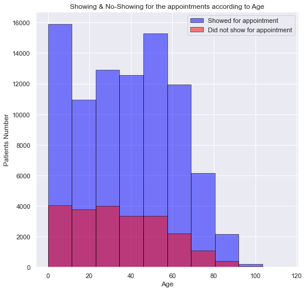

```python
plotting(df,'No_show','Age','hist',[8,8])
```

### **Research Question 2** (Does the **gender** influence showing for the appointment?)

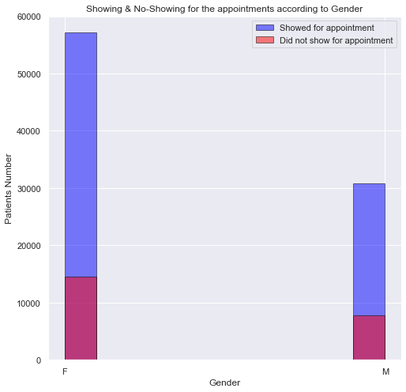

```python
plotting(df,'No_show','Gender','hist',[8,8])
```

```python
print_values(df,'No_show','Gender')
```

```
The Number of female patients who showed for the appointments is 57162 patients.
The Number of female patients who didn't show for the appointments is 14568 patients.
The Number of Male patients who showed for the appointments is 30887 patients.
The Number of Male patients who didn't show for the appointments is 7710 patients.
```

### **Research Question 3** (Which **Category** is likely to attend their appointments? 'Children,Women,Men, or Elderly people')

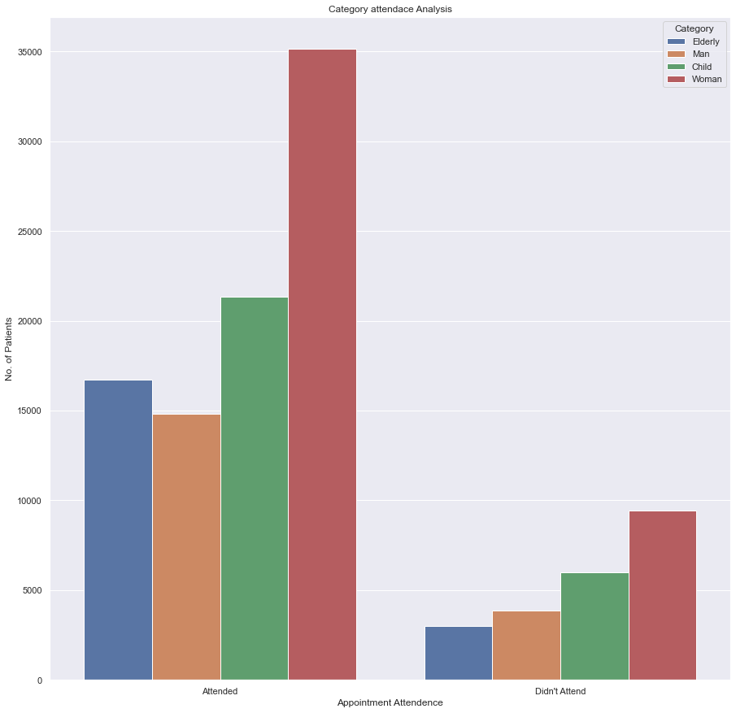

```python
df.loc[((df['No_show'] == 'No') ,'Attendance')] = 'Attended'
df.loc[((df['No_show'] == 'Yes'), 'Attendance')] = "Didn't Attend"
# Graph - Comapre the number of Men, Women and Children who showed up on their appointments
ax = sns.countplot(x = 'Attendance', hue = 'Category', data = df).set(title = 'Category attendace Analysis',
                                                                           xlabel="Appointment Attendence",
                                                                           ylabel='No. of Patients');
sns.set(rc = {'figure.figsize':(13,13)})
```

```python
# Printing The Number of categorized patients that attended their appointments and their percentage

child_att_perc = ((len(df[((df['Category'] == 'Child') &(df['No_show'] == 'No'))]) / len(df[(df['Category'] == 'Child')])) * 100)
child_att_no = len(df[((df['Category'] == 'Child') &(df['No_show'] == 'No'))])
women_att_perc = ((len(df[((df['Category'] == 'Woman') &(df['No_show'] == 'No'))]) / len(df[(df['Category'] == 'Woman')])) * 100)
women_att_no = len(df[((df['Category'] == 'Woman') &(df['No_show'] == 'No'))])
men_att_perc = ((len(df[((df['Category'] == 'Man') &(df['No_show'] == 'No'))]) / len(df[(df['Category'] == 'Man')])) * 100)
men_att_no = len(df[((df['Category'] == 'Man') &(df['No_show'] == 'No'))])
elderly_att_perc = ((len(df[((df['Category'] == 'Elderly') &(df['No_show'] == 'No'))]) / len(df[(df['Category'] == 'Elderly')])) * 100)
elderly_att_no = len(df[((df['Category'] == 'Elderly') &(df['No_show'] == 'No'))])

print(f'The Number of Children who attended is {child_att_no} with percentage equals {child_att_perc} %')
print(f'The Number of Women who attended is {women_att_no} with percentage equals {women_att_perc} %')
print(f'The Number of Men who attended is {men_att_no} with percentage equals {men_att_perc} %')
print(f'The Number of Elderly who attended is {elderly_att_no} with percentage equals {elderly_att_perc} %')
print(df['Category'].value_counts())
```

```
The Number of Children who attended is 21346 with percentage equals 78.08750365817968 %
The Number of Women who attended is 35165 with percentage equals 78.82761712620488 %
The Number of Men who attended is 14835 with percentage equals 79.37399678972713 %
The Number of Elderly who attended is 16703 with percentage equals 84.82555482199989 %
Woman      44610
Child      27336
Elderly    19691
Man        18690
Name: Category, dtype: int64
```

### **Research Question 4** (Does enrolling in **Brazilian Welfare Program Bolsa Family** influence showing for the appointment)

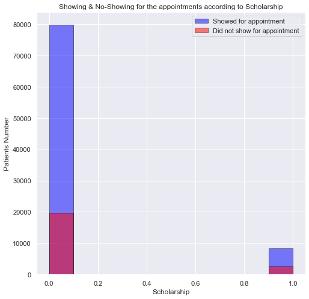

```python
plotting(df,'No_show','Scholarship','hist',[8,8])
```

```python
print_values(df,'No_show','Scholarship')

print(df['Scholarship'].value_counts())
```

```
The Number of patients who have Scholarship and showed for the appointments is 8266 patients.
The Number of patients who have Scholarship and didn't show for the appointments is 2577 patients.
The Number of patients who didn't have Scholarship and showed for the appointments is 79783 patients.
The Number of patients who didn't have Scholarship and didn't show for the appointments is 79783 patients.
0    99484
1    10843
Name: Scholarship, dtype: int64
```

According to the above chart and statistics **Scholarship Enrollment** The number of patients with scholarship doesn't have a major effect on the number of patients visiting the hospital on their appointment.

### **Research Question 5** (Does **Alcoholism** influence showing for the appointment?)

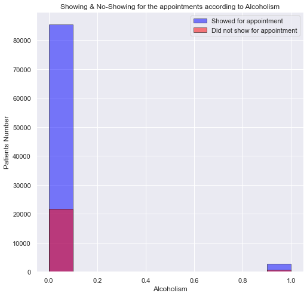

```python
plotting(df,'No_show','Alcoholism','hist',[8,8])
```

```python
print_values(df,'No_show','Alcoholism')

print(df['Alcoholism'].value_counts())
```

```
The Number of patients who have Alcoholism and showed for the appointments is 2677 patients.
The Number of patients who have Alcoholism and didn't show for the appointments is 675 patients.
The Number of patients who didn't have Alcoholism and showed for the appointments is 85372 patients.
The Number of patients who didn't have Alcoholism and didn't show for the appointments is 85372 patients.
0    106975
1      3352
Name: Alcoholism, dtype: int64
```

According to the above chart and statistics we can conclude that **Alcoholism** doesn't have a major influence on attending hospitals' appointments.

### **Research Question 6** (Does **handicapping** influence showing for the appointment?)

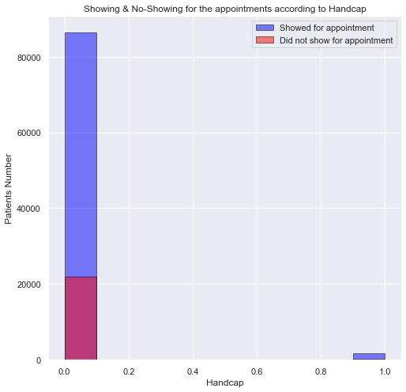

```python
plotting(df,'No_show','Handcap','hist',[8,8])
```

```python
print_values(df,'No_show','Handcap')
print(df['Handcap'].value_counts())
```

```
The Number of patients who have Handcap and showed for the appointments is 1676 patients.
The Number of patients who have Handcap and didn't show for the appointments is 366 patients.
The Number of patients who didn't have Handcap and showed for the appointments is 86373 patients.
The Number of patients who didn't have Handcap and didn't show for the appointments is 86373 patients.
0    108285
1      2042
Name: Handcap, dtype: int64
```

According to the above chart and statistics we can conclude that **Handicapping** doesn't have a major influence on attending hospitals' appointments.

### **Research Question 7** (Does **chronic diseases (Hypertension & Diabetes)** influence showing for the appointment?)

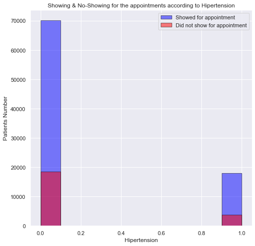

```python
plotting(df,'No_show','Hipertension','hist',[8,8])
```

```python
print_values(df,'No_show','Hipertension')
print(df['Hipertension'].value_counts())
```

```
The Number of patients who have Hipertension and showed for the appointments is 17968 patients.
The Number of patients who have Hipertension and didn't show for the appointments is 3748 patients.
The Number of patients who didn't have Hipertension and showed for the appointments is 70081 patients.
The Number of patients who didn't have Hipertension and didn't show for the appointments is 70081 patients.
0    88611
1    21716
Name: Hipertension, dtype: int64
```

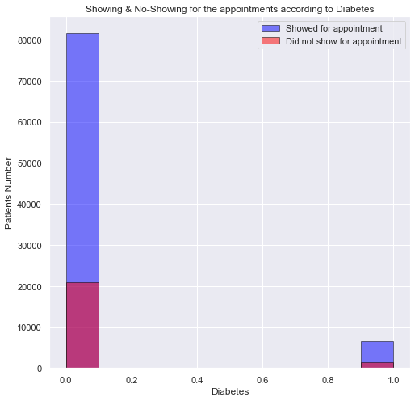

```python
plotting(df,'No_show','Diabetes','hist',[8,8])
```

```python
print_values(df,'No_show','Diabetes')
print(df['Diabetes'].value_counts())
```

```
The Number of patients who have Diabetes and showed for the appointments is 6478 patients.
The Number of patients who have Diabetes and didn't show for the appointments is 1422 patients.
The Number of patients who didn't have Diabetes and showed for the appointments is 81571 patients.
The Number of patients who didn't have Diabetes and didn't show for the appointments is 81571 patients.
0    102427
1      7900
Name: Diabetes, dtype: int64
```

According to the above chart and statistics we can conclude that **Chronic Diseases** doesn't have a major influence on attending hospitals' appointments.

### **Research Question 8** (Does receiving **Reminding SMS** influence showing for the appointment?)

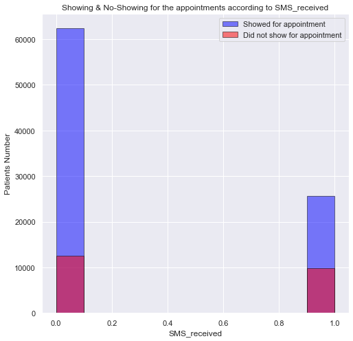

```python
plotting(df,'No_show','SMS_received','hist',[8,8])
```

According to the results, **Sending a reminder SMS** doesn't reinforce the probability of patients to attend the appointment which is a little bit strange as the people who received SMS & does show for the appointment is way less than people who didn't receive SMS and showed for the appointment.

### **Research Question 9** (Does **neighbourhood** where patients live at influence showing for the appointment?)

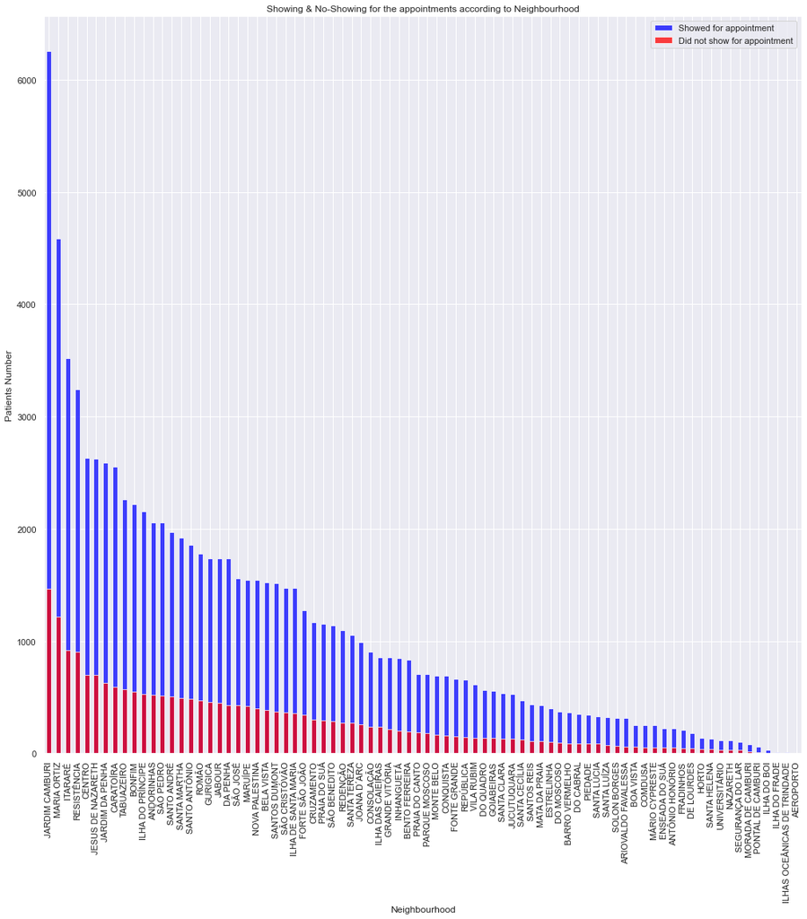

```python
plotting(df,'No_show','Neighbourhood','bar',[17,17])
```

It is very obvious that the **Neighbourhood** affects the number of patients shows for the appointments at the clinic.

## Conclusions

While for other points it was Shocking that Receving an SMS as a reminder to the patients about their appointments doesn't affect their attendance, which takes as to maybe consider to advance to next level to make sure that the patient remember his/here appointment maybe by making calls to them directlty to ensure that the reminder is succesfully received by the patient but financial wise it will be a heavy load on the hospitals.

While Analyzing with respect to neighbourhood that patients live at led us to a conclusion that this is a major point that affect attendance of patients as there is a major variation between the numbers of attending patients from different neighbourhoods but we must have data about those neighbourhoods to know the reasons of this variation and answer some questions about the distance of each neighbourhood to the clinics, if transportation is available or not.

**Limitations**:

- Lack of Information about **Neighbourhoods** which prevented deep analysis for the attendance with respect to the information of various neighbourhoods.
- There is no charactaristics equity in the samples, For example, The Number of **Handicapped** patients samples is very small with respect to the normal patients which can bias the judgement and conclusions if not noticed, These also found in many of other charactaristics.